# Experiments 1 to 4, comparison

Bodo Winter

7/3/2019

## Preliminaries:

Load packages:

```r
library(tidyverse)
library(brms)
library(lubridate)
```

Load in data:

```r
E1 <- read_csv('../data/cleaned_data/E1_cleaned.csv')
E2 <- read_csv('../data/cleaned_data/E2_cleaned.csv')
E3 <- read_csv('../data/cleaned_data/E3_cleaned.csv')
E4 <- read_csv('../data/cleaned_data/E4_cleaned.csv')
```

Get subsets for merging:

```r
E1 <- select(E1, Notice, Age, Gender,
             Gesture, IP, StartTime, Response) %>%
  rename(Direction = Gesture)
E2 <- select(E2, Notice, Age, Gender, Direction, IP, StartTime, Response, LikeScale)
E3 <- select(E3, Notice, Age, Gender, Direction, IP, StartTime, Response, LikeScale)
E4 <- select(E4, Notice, Age, Gender, Direction, IP, StartTime, Response, LikeScale)
```

Make the date formats the same and add experiment identifier:

```r
E1 <- mutate(E1,
             StartTime = as_datetime(StartTime),
             Experiment = 'Experiment 1')
E2 <- mutate(E2,
             StartTime = as_datetime(StartTime),
             Experiment = 'Experiment 2')
E3 <- mutate(E3,
             StartTime = as_datetime(StartTime),
             Experiment = 'Experiment 3')
E4 <- mutate(E4,
             StartTime = as_datetime(StartTime),
             Experiment = 'Experiment 4')
```

Merge those:

```r
xdata <- bind_rows(E1, E2, E3, E4)
```

What is the overall Monday/Friday responses? (Overview)

```r
xdata %>% count(Experiment, Response) %>%
  spread(Response, -Experiment) %>%
  mutate(FridayProp = Friday / (Friday + Monday),
         FridayProp = round(FridayProp, 2),
         MondayProp = 1 - FridayProp)
```

```
## # A tibble: 4 x 5
##   Experiment   Friday Monday FridayProp MondayProp
##   <chr>         <int>  <int>      <dbl>      <dbl>
## 1 Experiment 1     55    136      0.290      0.71
## 2 Experiment 2    112     87      0.56       0.440
## 3 Experiment 3     72    160      0.31       0.69
## 4 Experiment 4    191     49      0.8        0.200
```

Center the overall LikeScale variable:

```r
xdata <- mutate(xdata,
                LikeScale_c = LikeScale - mean(LikeScale, na.rm = TRUE),
                DirectionPlot = str_c(Direction, '\ngesture'),
                Direction = factor(Direction, levels = c('backward', 'forward')),
                DirectionPlot = factor(DirectionPlot, levels = c('backward\ngesture', 'forward\ngesture')))
```

Sum-code the Direction predictor:

```r
contrasts(xdata$Direction) <- contr.sum(2) / 2 * -1
```

Code the Monday/Friday effect so that it is consistent (with “Monday” being the reference level):

```r
xdata <- mutate(xdata,
                Response = factor(Response, levels = c('Monday', 'Friday')))
```

## Make a plot of the overall Monday/Friday responses:

Plot:

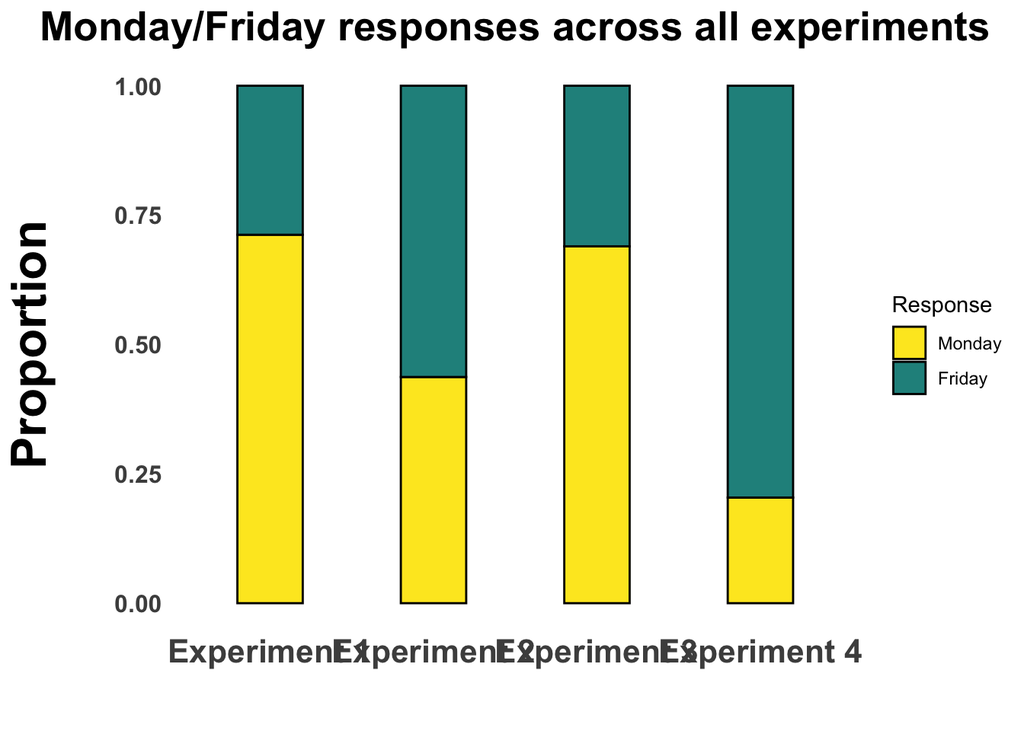

```r
xdata %>%
  count(Experiment, Response) %>%
  spread(Response, n) %>%
  mutate(Sum = Monday + Friday,
         Monday = Monday / Sum,
         Friday = Friday / Sum) %>%
  select(-Sum) %>%
  gather(key = 'Response', value = 'n',
         -Experiment) %>%
  mutate(Response = factor(Response,
                           levels = c('Monday', 'Friday'))) %>%
  rename(Proportion = n) %>%
  ggplot(aes(x = Experiment, y = Proportion, fill = Response)) +
  geom_bar(stat = 'identity', col = 'black',
           position = position_stack(reverse = TRUE),
           width = 0.4) +
  scale_fill_manual(values = c('#FDE725FF', '#21908CFF')) +
  theme_minimal() +
  theme(legend.position = 'right') +
  labs(title = 'Monday/Friday responses across all experiments') +
  ylab('Proportion\n') +
  xlab('') +
  theme(plot.title = element_text(face = 'bold', size = 20, hjust = 0.5),
        axis.title = element_text(face = 'bold', size = 24),
        axis.text.x = element_text(face = 'bold', size = 16),
        axis.text.y = element_text(face = 'bold', size = 12),
        plot.caption = element_text(size = 14),
        panel.grid.minor = element_blank(),
        panel.grid.major = element_blank())
```

```r
ggsave('../figures/all_experiments.png', width = 10, height = 4)
```

## Does likeability explain the by-experiment differences?

What is the average likeability acrosss experiments?

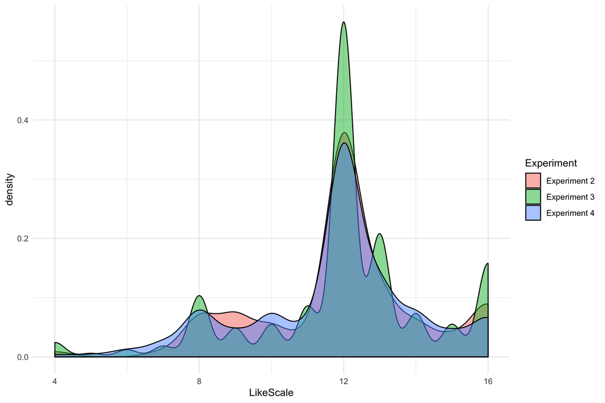

```r
xdata %>%
  filter(Experiment != 'Experiment 1') %>%
  ggplot(aes(x = LikeScale, fill = Experiment)) +
  geom_density(alpha = 0.5) + theme_minimal()
```

What is the average likeability acrosss experiments?

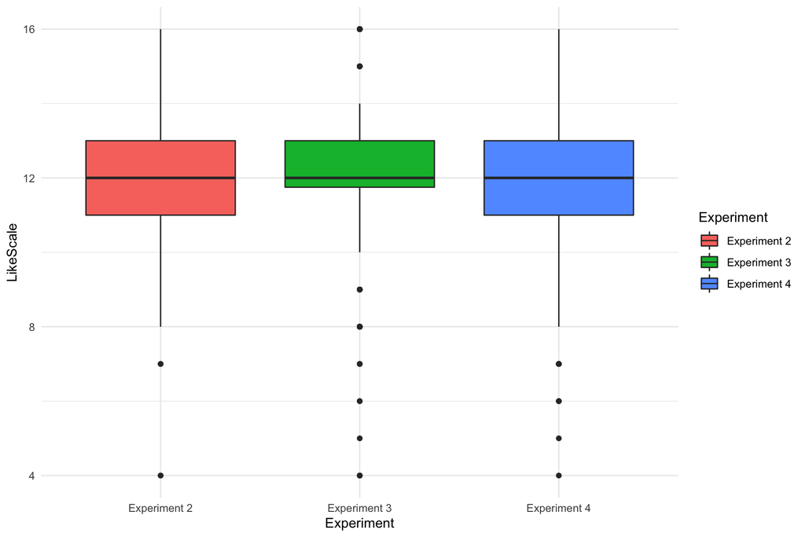

```r
xdata %>%
  filter(Experiment != 'Experiment 1') %>%
  ggplot(aes(x = Experiment, fill = Experiment, y = LikeScale)) +
  geom_boxplot() + theme_minimal()
```

Test this:

Set the parameters for a Bayesian analysis:

```r
# For parallel processing:

options(mc.cores=parallel::detectCores())

# For handling the MCMC sampling:

my_controls <- list(adapt_delta = 0.99,
                    max_treedepth = 13)
```

Set regularizing priors on betas:

```r
my_priors <- c(prior(normal(0, 1), class = b))
```

Specify and run the model:

```r
like_mdl <- brm(LikeScale ~ Experiment,
              data = filter(xdata, Experiment != 'Experiment 1'),
              family = poisson,
              init = 0,
              chains = 8,
              warmup = 2000,
              iter = 8000,
              seed = 42,
              prior = my_priors,
              control = my_controls)
like_null <- brm(LikeScale ~ Experiment,
              data = filter(xdata, Experiment != 'Experiment 1'),
              family = poisson,
              init = 0,
              chains = 8,
              warmup = 2000,
              iter = 8000,
              seed = 42,
              control = my_controls)
save(like_mdl, file = '../models/like_mdl.RData')
save(like_null, file = '../models/like_null.RData')
```

Check model:

```r
summary(like_mdl)
```

```
##  Family: poisson
##   Links: mu = log
## Formula: LikeScale ~ Experiment
##    Data: filter(xdata, Experiment != "Experiment 1") (Number of observations: 671)
## Samples: 8 chains, each with iter = 8000; warmup = 2000; thin = 1;
##          total post-warmup samples = 48000
##
## Population-Level Effects:
##                       Estimate Est.Error l-95% CI u-95% CI Eff.Sample Rhat
## Intercept                 2.48      0.02     2.44     2.52      24808 1.00
## ExperimentExperiment3     0.00      0.03    -0.05     0.06      25867 1.00
## ExperimentExperiment4    -0.01      0.03    -0.07     0.04      26408 1.00
##
## Samples were drawn using sampling(NUTS). For each parameter, Eff.Sample
## is a crude measure of effective sample size, and Rhat is the potential
## scale reduction factor on split chains (at convergence, Rhat = 1).
```

Compare loos:

```r
like_loo <- loo(like_mdl, reloo = TRUE)
```

```
## No problematic observations found. Returning the original 'loo' object.
```

```r
like_loo_null <- loo(like_null, reloo = TRUE)
```

```
## No problematic observations found. Returning the original 'loo' object.
```

```r
loo_compare(like_loo_null, like_loo)
```

```
##           elpd_diff se_diff
## like_mdl  0.0       0.0
## like_null 0.0       0.0
```

Not much going on. Check marginal effects:

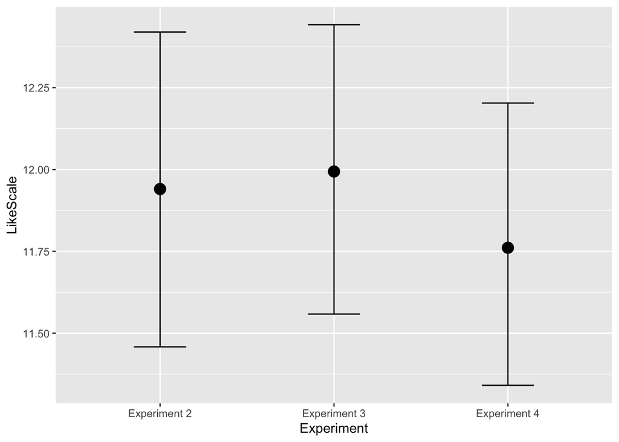

```r
marginal_effects(like_mdl, effects = 'Experiment')
```

Extremely overlapping. So the overall differences don’t seem to be due to likeability.

## Across model influence of likeability:

Perform analysis:

```r
all_social_mdl <- brm(Response ~ Direction * LikeScale_c,
              data = xdata,
              family = bernoulli,
              init = 0,
              chains = 8,
              warmup = 2000,
              iter = 8000,
              seed = 42,
              prior = my_priors,
              control = my_controls)
save(all_social_mdl, file = '../models/all_social_mdl.RData')
```

Summarize:

```r
summary(all_social_mdl)
```

```
##  Family: bernoulli
##   Links: mu = logit
## Formula: Response ~ Direction * LikeScale_c
##    Data: xdata (Number of observations: 671)
## Samples: 8 chains, each with iter = 8000; warmup = 2000; thin = 1;
##          total post-warmup samples = 48000
##
## Population-Level Effects:
##                        Estimate Est.Error l-95% CI u-95% CI Eff.Sample
## Intercept                  0.29      0.08     0.13     0.46      44373
## Direction1                 1.27      0.17     0.95     1.60      45983
## LikeScale_c               -0.01      0.03    -0.08     0.06      47319
## Direction1:LikeScale_c     0.19      0.07     0.05     0.32      46105
##                        Rhat
## Intercept              1.00
## Direction1             1.00
## LikeScale_c            1.00
## Direction1:LikeScale_c 1.00
##
## Samples were drawn using sampling(NUTS). For each parameter, Eff.Sample
## is a crude measure of effective sample size, and Rhat is the potential
## scale reduction factor on split chains (at convergence, Rhat = 1).
```

Load social models:

```r
load('../models/E2_social_mdl.RData')
load('../models/E3_social_mdl.RData')
load('../models/E4_social_mdl.RData')
```

Get the posteriors of each model:

```r
E2_post <- posterior_samples(E2_social_mdl)
E3_post <- posterior_samples(E3_social_mdl)
E4_post <- posterior_samples(E4_social_mdl)
all_post <- posterior_samples(all_social_mdl)
```

Extract the interaction coefficients:

```r
E2_int <- E2_post$`b_Direction1:LikeScale_c`
E3_int <- E3_post$`b_Direction1:LikeScale_c`
E4_int <- E4_post$`b_Direction1:LikeScale_c`
all_int <- all_post$`b_Direction1:LikeScale_c`
```

Check the posterior probability of the overall coefficient being above zero:

```r
sum(all_int > 0) / length(all_int)
```

```
## [1] 0.9965208
```

If we check how many of the posteriors together are over 0:

```r
all_posts <- c(E2_int, E3_int, E4_int)
1 - sum(all_posts > 0) / length(all_posts)
```

```
## [1] 0.04740972
```

Get them all into one table for plotting:

```r
like_tib <- tibble(Experiment = c('Experiment 2', 'Experiment 3', 'Experiment 4', 'All'),
                   M = c(mean(E2_int), mean(E3_int), mean(E4_int), mean(all_int)),
       LB = c(quantile(E2_int, 0.025), quantile(E3_int, 0.025), quantile(E4_int, 0.025), quantile(all_int, 0.025)),
       UB = c(quantile(E2_int, 0.975), quantile(E3_int, 0.975), quantile(E4_int, 0.975), quantile(all_int, 0.975))) %>%
  mutate(Experiment = factor(Experiment,
                             levels = c('Experiment 2', 'Experiment 3', 'Experiment 4', 'All')))
```

Make a plot of this:

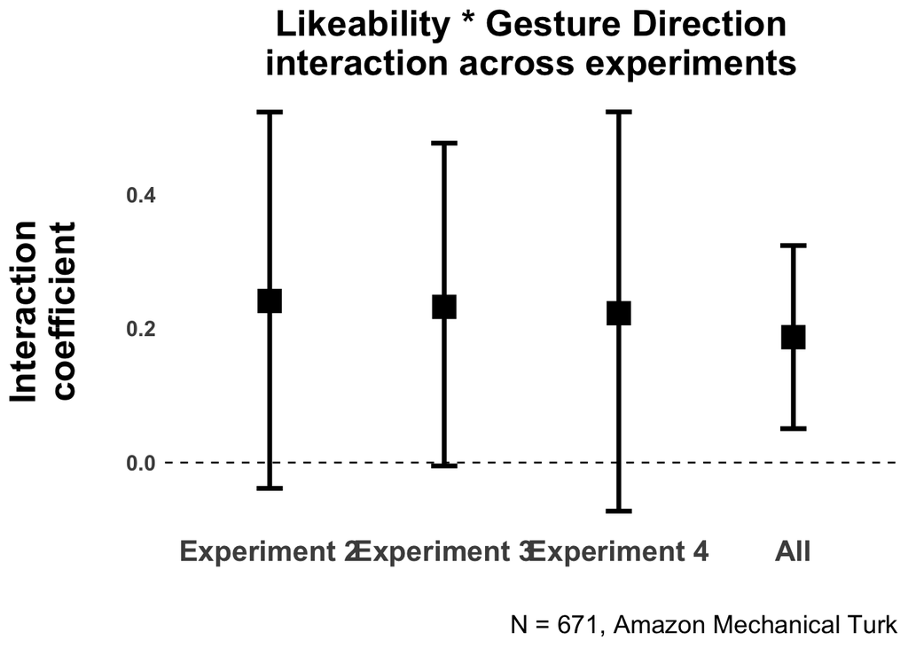

```r
like_tib %>%
  ggplot(aes(x = Experiment, y = M)) +
  geom_errorbar(aes(ymin = LB, ymax = UB), width = 0.15, lwd = 1.25) +
  geom_hline(aes(yintercept = 0), linetype = 2) +
  geom_point(size = 6, pch = 15) +
  xlab('') +
  ylab('Interaction\ncoefficient\n') +
  labs(title = 'Likeability * Gesture Direction\ninteraction across experiments',
       caption = str_c('N = ', nrow(filter(xdata, Experiment != 'Experiment 1')), ', Amazon Mechanical Turk')) +
  theme_minimal() +
  theme(plot.title = element_text(face = 'bold', size = 20, hjust = 0.5),
        axis.title = element_text(face = 'bold', size = 20),
        axis.text.x = element_text(face = 'bold', size = 16),
        axis.text.y = element_text(face = 'bold', size = 12),
        strip.text.x = element_text(face = 'bold', size = 20),
        plot.caption = element_text(size = 14),
        panel.grid.minor = element_blank(),
        panel.grid.major = element_blank())
```

```r
ggsave('../figures/likeability1.png', width = 10.5, height = 5)
```

## Make a plot of the high versus low likeables:

Look at the distribution of like scale to see what a median split would do:

```r
xdata %>% filter(!is.na(LikeScale)) %>%
  count(LikeScale) %>%
  mutate(Prop = n / sum(n))
```

```
## # A tibble: 13 x 3
##    LikeScale     n    Prop
##        <dbl> <int>   <dbl>
##  1         4     7 0.0104
##  2         5     2 0.00298
##  3         6     5 0.00745
##  4         7    11 0.0164
##  5         8    52 0.0775
##  6         9    33 0.0492
##  7        10    38 0.0566
##  8        11    33 0.0492
##  9        12   272 0.405
## 10        13    87 0.130
## 11        14    42 0.0626
## 12        15    26 0.0387
## 13        16    63 0.0939
```

What is the median in comparison to this?

```r
median(xdata$LikeScale, na.rm = TRUE)
```

```
## [1] 12
```

Look at above and below median, but exclude the median since counting it towards either the “low” or “high” category would skew the results and since this is the largest number of them.

```r
like_only <- xdata %>%
  filter(!is.na(LikeScale)) %>%
  filter(LikeScale != 12) %>%
mutate(LikeMedian = ifelse(LikeScale > 12, 'high likeability', 'low likeability'),
         LikeMedian = factor(LikeMedian,
                             levels = c('low likeability', 'high likeability')))
```

Look at the counts of this:

```r
like_tab <- with(like_only, table(Direction, Response, LikeMedian))
low <- like_tab[, , 1]
high <- like_tab[, , 2]
low
```

```
##           Response
## Direction  Monday Friday
##   backward     46     39
##   forward      31     65
```

```r
high
```

```
##           Response
## Direction  Monday Friday
##   backward     85     36
##   forward      21     76
```

```r
round(prop.table(low, 1), 2)
```

```
##           Response
## Direction  Monday Friday
##   backward   0.54   0.46
##   forward    0.32   0.68
```

```r
round(prop.table(high, 1), 2)
```

```
##           Response
## Direction  Monday Friday
##   backward   0.70   0.30
##   forward    0.22   0.78
```

Make a plot of this:

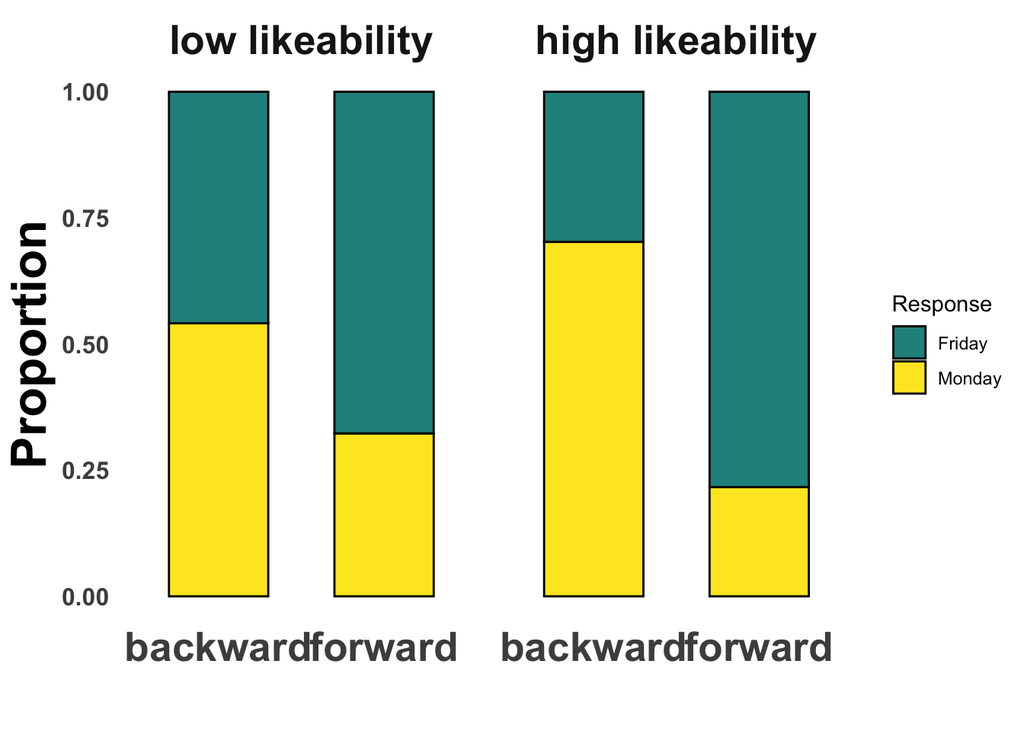

```r
like_only %>% group_by(LikeMedian, Direction) %>%
  count(Response) %>%
  spread(Response, n, fill = 0) %>%
  mutate(Friday = Friday / (Friday + Monday),
         Monday = 1 - Friday) %>%
  gather(key = 'Response', value = 'Proportion', -c(LikeMedian:Direction)) %>%
  ggplot(aes(x = Direction, y = Proportion, fill = Response)) +
  geom_bar(stat = 'identity', col = 'black', width = 0.6) +
  scale_fill_manual(values = c('#21908CFF', '#FDE725FF')) +
  facet_wrap(~LikeMedian) +
  xlab('') +
  theme_minimal() +
  theme(plot.title = element_text(face = 'bold', size = 20, hjust = 0.5),
        axis.title = element_text(face = 'bold', size = 24),
        axis.text.x = element_text(face = 'bold', size = 20),
        axis.text.y = element_text(face = 'bold', size = 12),
        strip.text.x = element_text(face = 'bold', size = 20),
        plot.caption = element_text(size = 14),
        panel.grid.minor = element_blank(),
        panel.grid.major = element_blank())
```

```r
ggsave('../figures/likeability_median_split.png', width = 9, height = 5)
```

## Does likeability influence gesture awareness?

Factor code noticing (from least to most) for plotting and easy reporting:

```r
mylevs <- c('Definitely not', 'Probably not',
            'Might or might not', 'Probably yes',
            'Definitely yes')
xdata <- mutate(xdata,
                Notice = factor(Notice, levels = mylevs))
```

Check whether likeability could influence noticing with a plot:

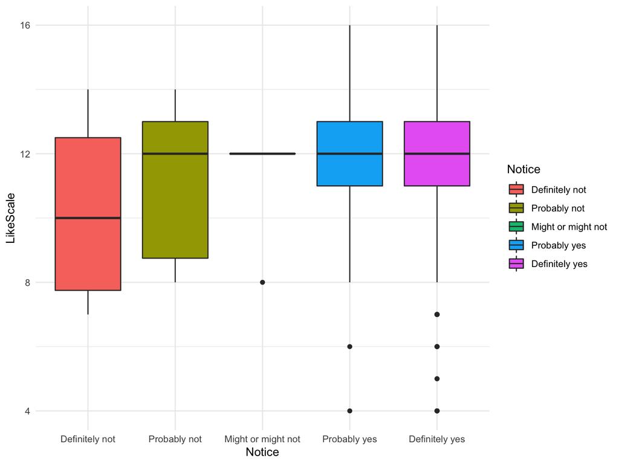

```r
xdata %>% ggplot(aes(x = Notice, y = LikeScale, fill = Notice)) +
  geom_boxplot() + theme_minimal()
```

Look at awareness across experiments:

```r
with(xdata, table(Experiment, Notice))
```

```
##               Notice
## Experiment     Definitely not Probably not Might or might not Probably yes
##   Experiment 1              1            2                  1           11
##   Experiment 2              2            4                  2           34
##   Experiment 3              2            2                  2           27
##   Experiment 4              0            4                  4           29
##               Notice
## Experiment     Definitely yes
##   Experiment 1            176
##   Experiment 2            157
##   Experiment 3            199
##   Experiment 4            203
```

```r
round(prop.table(with(xdata, table(Experiment, Notice)), 1), 2)
```

```
##               Notice
## Experiment     Definitely not Probably not Might or might not Probably yes
##   Experiment 1           0.01         0.01               0.01         0.06
##   Experiment 2           0.01         0.02               0.01         0.17
##   Experiment 3           0.01         0.01               0.01         0.12
##   Experiment 4           0.00         0.02               0.02         0.12
##               Notice
## Experiment     Definitely yes
##   Experiment 1           0.92
##   Experiment 2           0.79
##   Experiment 3           0.86
##   Experiment 4           0.85
```

Report means:

```r
xdata %>% group_by(Notice) %>%
  summarize(M = mean(LikeScale, na.rm = TRUE))
```

```
## # A tibble: 5 x 2
##   Notice                 M
##   <fct>              <dbl>
## 1 Definitely not      10.2
## 2 Probably not        11.3
## 3 Might or might not  11.5
## 4 Probably yes        11.6
## 5 Definitely yes      12.0
```

Make a model of this, des likeability influence gesture awareness?

```r
xdata <- mutate(xdata,
                Notice = as.ordered(Notice))
awareness_mdl <- brm(Notice ~ LikeScale,
              data = xdata,
              family = cumulative('logit'),
              init = 0,
              chains = 8,
              warmup = 2000,
              iter = 8000,
              seed = 42,
              prior = my_priors,
              control = my_controls)
save(awareness_mdl, file = '../models/awareness_mdl.RData')
```

Check this model:

```r
summary(awareness_mdl)
```

```
##  Family: cumulative
##   Links: mu = logit; disc = identity
## Formula: Notice ~ LikeScale
##    Data: xdata (Number of observations: 671)
## Samples: 8 chains, each with iter = 8000; warmup = 2000; thin = 1;
##          total post-warmup samples = 48000
##
## Population-Level Effects:
##              Estimate Est.Error l-95% CI u-95% CI Eff.Sample Rhat
## Intercept[1]    -4.46      0.73    -5.94    -3.11      26760 1.00
## Intercept[2]    -3.03      0.56    -4.16    -1.95      38435 1.00
## Intercept[3]    -2.51      0.54    -3.59    -1.48      39263 1.00
## Intercept[4]    -0.71      0.50    -1.71     0.26      39296 1.00
## LikeScale        0.08      0.04    -0.01     0.16      38968 1.00
##
## Samples were drawn using sampling(NUTS). For each parameter, Eff.Sample
## is a crude measure of effective sample size, and Rhat is the potential
## scale reduction factor on split chains (at convergence, Rhat = 1).
```

Check whether the relationship between likeability and gesture direction still holds even if the awareness is controlled for:

```r
social_notice_mdl <- brm(Response ~ Direction * LikeScale_c +
                       Notice + Notice:LikeScale_c,
              data = xdata,
              family = bernoulli,
              init = 0,
              chains = 8,
              warmup = 2000,
              iter = 8000,
              seed = 42,
              prior = my_priors,
              control = my_controls)
```

```
## recompiling to avoid crashing R session
```

```r
save(social_notice_mdl, file = '../models/social_notice_mdl.RData')
```

Summarize this model:

```r
summary(social_notice_mdl)
```

```
##  Family: bernoulli
##   Links: mu = logit
## Formula: Response ~ Direction * LikeScale_c + Notice + Notice:LikeScale_c
##    Data: xdata (Number of observations: 671)
## Samples: 8 chains, each with iter = 8000; warmup = 2000; thin = 1;
##          total post-warmup samples = 48000
##
## Population-Level Effects:
##                        Estimate Est.Error l-95% CI u-95% CI Eff.Sample
## Intercept                  0.31      0.30    -0.28     0.91      52318
## Direction1                 1.29      0.17     0.97     1.62      57519
## LikeScale_c               -0.01      0.21    -0.43     0.42      24008
## Notice.L                   0.30      0.65    -0.97     1.59      40372
## Notice.Q                  -0.50      0.60    -1.68     0.67      34006
## Notice.C                   0.04      0.48    -0.91     1.00      36370
## NoticeE4                   0.28      0.57    -0.84     1.42      47592
## Direction1:LikeScale_c     0.20      0.07     0.06     0.34      55170
## LikeScale_c:Notice.L       0.61      0.43    -0.11     1.58      21340
## LikeScale_c:Notice.Q      -1.12      0.51    -2.21    -0.21      24853
## LikeScale_c:Notice.C       0.53      0.29    -0.00     1.15      27880
## LikeScale_c:NoticeE4       0.35      0.54    -0.60     1.52      28269
##                        Rhat
## Intercept              1.00
## Direction1             1.00
## LikeScale_c            1.00
## Notice.L               1.00
## Notice.Q               1.00
## Notice.C               1.00
## NoticeE4               1.00
## Direction1:LikeScale_c 1.00
## LikeScale_c:Notice.L   1.00
## LikeScale_c:Notice.Q   1.00
## LikeScale_c:Notice.C   1.00
## LikeScale_c:NoticeE4   1.00
##
## Samples were drawn using sampling(NUTS). For each parameter, Eff.Sample
## is a crude measure of effective sample size, and Rhat is the potential
## scale reduction factor on split chains (at convergence, Rhat = 1).
```

Check the posterior probabilities:

```r
social_posts <- posterior_samples(social_notice_mdl)

# Posterior probability of interaction being > 0:

sum(social_posts$'b_Direction1:LikeScale_c' > 0) / nrow(social_posts)
```

```
## [1] 0.9970625
```

## Exploring the influence of individual differences:

Look at the age effect:

```r
library(Hmisc)
xdata <- mutate(xdata,
                Age_c = cut2(Age, g = 10))
```

Plot this across time:

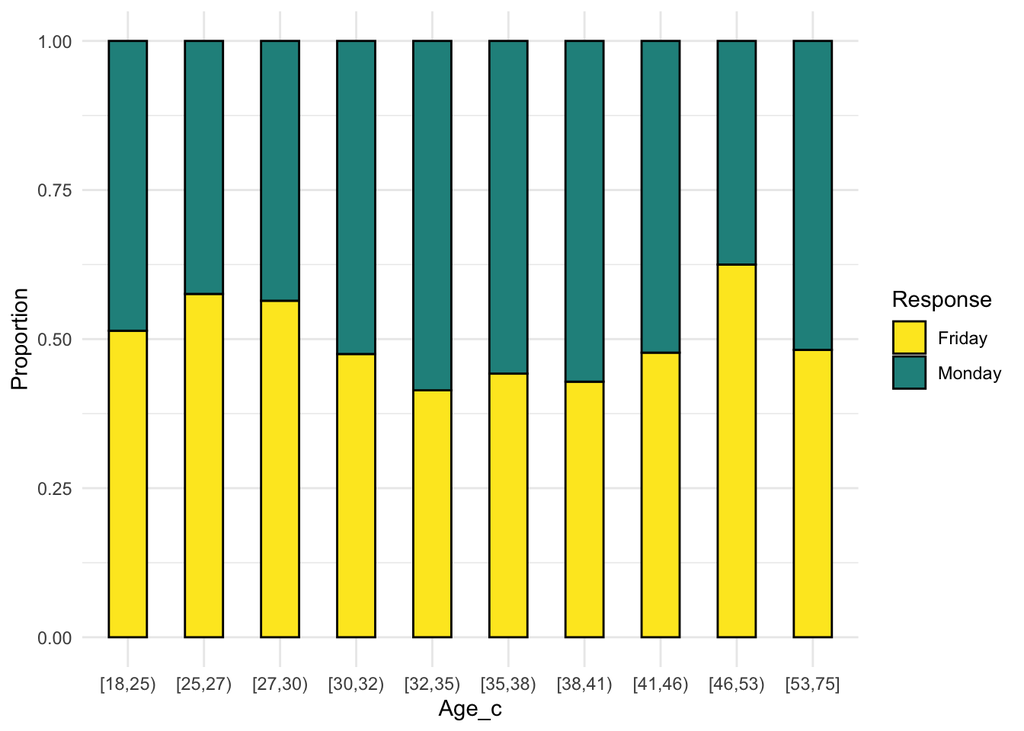

```r
xdata %>%
  count(Age_c, Response) %>%
  spread(Response, -Age_c) %>%
  mutate(Sum = Monday + Friday,
         Monday = Monday / Sum,
         Friday = Friday / Sum) %>%
  gather(key = 'Response', value = 'Proportion', -Age_c) %>%
  filter(Response != 'Sum') %>%
  ggplot(aes(x = Age_c, y = Proportion, fill = Response)) +
  geom_bar(stat = 'identity', col = 'black',
           position = position_stack(reverse = TRUE),
           width = 0.5) +
    scale_fill_manual(values = c('#FDE725FF', '#21908CFF')) +
  theme_minimal() +
  theme(legend.position = 'right')
```

Looks to be a small pattern.

Let’s look at gender. First, do they overall respond with more Monday’s or Friday’s?

```r
gen_tab <- with(xdata, table(Gender, Response))
gen_tab
```

```
##         Response
## Gender   Monday Friday
##   female    160    206
##   male      271    220
##   other       1      4
```

```r
round(prop.table(gen_tab, 1), 2)
```

```
##         Response
## Gender   Monday Friday
##   female   0.44   0.56
##   male     0.55   0.45
##   other    0.20   0.80
```

Wmen report slightly more “Friday” responses, men slightly more “Monday” responses. The “other” category should be discounted since it’s only 5 responses (not enough to be reliable).

Check what the direction effect is:

```r
gen_tab <- with(xdata, table(Direction, Response, Gender))
men <- gen_tab[, , 2]
women <- gen_tab[, , 1]
```

Look at this:

```r
men
```

```
##           Response
## Direction  Monday Friday
##   backward    177     93
##   forward      94    127
```

```r
women
```

```
##           Response
## Direction  Monday Friday
##   backward    100     72
##   forward      60    134
```

Proportions:

```r
prop.table(men, 1)
```

```
##           Response
## Direction     Monday    Friday
##   backward 0.6555556 0.3444444
##   forward  0.4253394 0.5746606
```

```r
prop.table(women, 1)
```

```
##           Response
## Direction     Monday    Friday
##   backward 0.5813953 0.4186047
##   forward  0.3092784 0.6907216
```

For modeling the gender effect, we need to exclude the “other” category (too few data points).

```r
gen_only <- xdata %>%
  filter(Gender != 'other') %>%
  mutate(Gender = factor(Gender, levels = c('male', 'female')))
contrasts(gen_only$Gender) <- contr.sum(2) / 2 * -1
```

Check:

```r
contrasts(gen_only$Gender)
```

```
##        [,1]
## male   -0.5
## female  0.5
```

In this particular analysis, men are coded as -0.5, and women as +0.5.

Model the gender effect:

```r
gender_mdl <- brm(Response ~ Direction * (Gender + LikeScale_c),
                  data = gen_only,
              family = bernoulli,
              init = 0,
              chains = 8,
              warmup = 2000,
              iter = 8000,
              seed = 42,
              prior = my_priors,
              control = my_controls)
```

```
## recompiling to avoid crashing R session
```

```r
save(gender_mdl, file = '../models/gender_mdl.RData')
```

Summarize this:

```r
summary(gender_mdl)
```

```
##  Family: bernoulli
##   Links: mu = logit
## Formula: Response ~ Direction * (Gender + LikeScale_c)
##    Data: gen_only (Number of observations: 666)
## Samples: 8 chains, each with iter = 8000; warmup = 2000; thin = 1;
##          total post-warmup samples = 48000
##
## Population-Level Effects:
##                        Estimate Est.Error l-95% CI u-95% CI Eff.Sample
## Intercept                  0.31      0.08     0.14     0.47      56692
## Direction1                 1.28      0.17     0.95     1.61      54867
## Gender1                    0.32      0.17    -0.00     0.65      54811
## LikeScale_c               -0.01      0.03    -0.08     0.06      54639
## Direction1:Gender1         0.14      0.32    -0.49     0.77      55939
## Direction1:LikeScale_c     0.19      0.07     0.05     0.32      55060
##                        Rhat
## Intercept              1.00
## Direction1             1.00
## Gender1                1.00
## LikeScale_c            1.00
## Direction1:Gender1     1.00
## Direction1:LikeScale_c 1.00
##
## Samples were drawn using sampling(NUTS). For each parameter, Eff.Sample
## is a crude measure of effective sample size, and Rhat is the potential
## scale reduction factor on split chains (at convergence, Rhat = 1).
```

The likeability effect is still strong! There seems to be a gender effect with women reporting more Friday’s then men!

## Exploring the influence of the time of the day:

Extract time of the day information:

```r
library(hms)
xdata <- mutate(xdata,
                Time = as.hms(StartTime),
                Hour = hour(Time))
```

Check counts:

```r
myhours <- xdata %>% count(Hour)
myhours
```

```
## # A tibble: 16 x 2
##     Hour     n
##    <int> <int>
##  1     2    20
##  2     5    10
##  3     6     3
##  4     7    14
##  5     8    26
##  6     9    92
##  7    10    97
##  8    11   124
##  9    12    59
## 10    13    38
## 11    14    19
## 12    15     3
## 13    16    28
## 14    17    22
## 15    18   305
## 16    19     2
```

The problem with this information is that it doesn’t look at time zone, and America covers several time zones. So we cannot really use this to disentangle the effects of time versus the effects of population (e.g., East Coasters versus West Coasters, which would be signing on to Amazon Mechanical Turk at different times).

```r
these_hours <- filter(myhours, n < 20) %>% pull(Hour)
```

Plot time of the day against Monday/Friday responses:

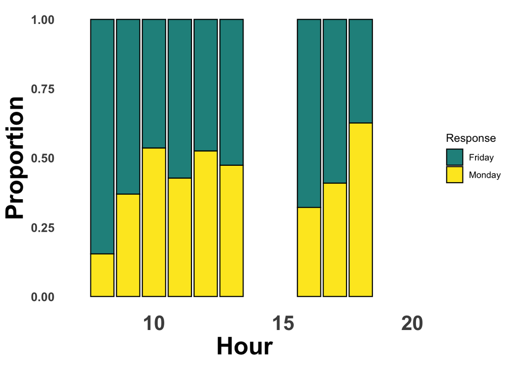

```r
xdata %>% group_by(Hour) %>%
  count(Response) %>%
  spread(Response, n, fill = 0) %>%
  mutate(Friday = Friday / (Friday + Monday),
         Monday = 1 - Friday) %>%
  gather(key = 'Response', value = 'Proportion', -Hour) %>%
  filter(!Hour %in% these_hours) %>%
  filter(Hour > 5) %>%
  ggplot(aes(x = Hour, y = Proportion, fill = Response)) +
  scale_x_continuous(limits = c(7, 20)) +
  geom_bar(stat = 'identity', col = 'black', width = 0.9) +
  scale_fill_manual(values = c('#21908CFF', '#FDE725FF')) +
  theme_minimal() +
  theme(plot.title = element_text(face = 'bold', size = 20, hjust = 0.5),
        axis.title = element_text(face = 'bold', size = 24),
        axis.text.x = element_text(face = 'bold', size = 20),
        axis.text.y = element_text(face = 'bold', size = 12),
        strip.text.x = element_text(face = 'bold', size = 20),
        plot.caption = element_text(size = 14),
        panel.grid.minor = element_blank(),
        panel.grid.major = element_blank())
```

```r
ggsave('../figures/time_response.png', width = 11, height = 4)
```

Check whether there is an effect:

```r
time_mdl <- brm(Response ~ Hour,
              data = xdata,
              family = bernoulli,
              init = 0,
              chains = 8,
              warmup = 2000,
              iter = 8000,
              seed = 42,
              prior = my_priors,
              control = my_controls)
```

```
## recompiling to avoid crashing R session
```

```r
time_null <- brm(Response ~ 1,
              data = xdata,
              family = bernoulli,
              init = 0,
              chains = 8,
              warmup = 2000,
              iter = 8000,
              seed = 42,
              control = my_controls)
save(time_mdl, file = '../models/time_mdl.RData')
save(time_null, file = '../models/time_null.RData')
```

Check:

```r
summary(time_mdl)
```

```
##  Family: bernoulli
##   Links: mu = logit
## Formula: Response ~ Hour
##    Data: xdata (Number of observations: 862)
## Samples: 8 chains, each with iter = 8000; warmup = 2000; thin = 1;
##          total post-warmup samples = 48000
##
## Population-Level Effects:
##           Estimate Est.Error l-95% CI u-95% CI Eff.Sample Rhat
## Intercept     1.06      0.23     0.61     1.51      26771 1.00
## Hour         -0.08      0.02    -0.11    -0.05      26530 1.00
##
## Samples were drawn using sampling(NUTS). For each parameter, Eff.Sample
## is a crude measure of effective sample size, and Rhat is the potential
## scale reduction factor on split chains (at convergence, Rhat = 1).
```

Do a posterior predictive check on this:

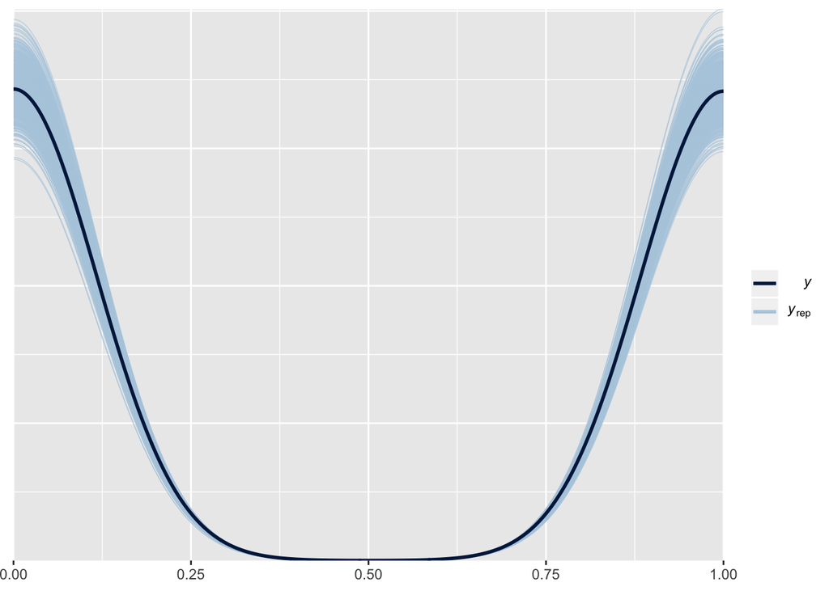

```r
pp_check(time_mdl, nsamples = 1000)
```

## Exploring the influence of the week day:

Use week days information:

```r
xdata <- mutate(xdata,
                WeekDay = weekdays(StartTime))
```

Count week days:

```r
xdata %>% count(WeekDay)
```

```
## # A tibble: 7 x 2
##   WeekDay       n
##   <chr>     <int>
## 1 Friday      245
## 2 Monday       39
## 3 Saturday    243
## 4 Sunday       74
## 5 Thursday    218
## 6 Tuesday       1
## 7 Wednesday    42
```

Count week days per Experiment:

```r
xdata %>% count(Experiment, WeekDay)
```

```
## # A tibble: 11 x 3
##    Experiment   WeekDay       n
##    <chr>        <chr>     <int>
##  1 Experiment 1 Monday       39
##  2 Experiment 1 Saturday     16
##  3 Experiment 1 Sunday       74
##  4 Experiment 1 Thursday     19
##  5 Experiment 1 Tuesday       1
##  6 Experiment 1 Wednesday    42
##  7 Experiment 2 Thursday    199
##  8 Experiment 3 Friday      121
##  9 Experiment 3 Saturday    111
## 10 Experiment 4 Friday      124
## 11 Experiment 4 Saturday    116
```

Proportions of “Monday/Friday” responses per day:

```r
with(xdata, table(WeekDay, Response))
```

```
##            Response
## WeekDay     Monday Friday
##   Friday       103    142
##   Monday        30      9
##   Saturday     116    127
##   Sunday        53     21
##   Thursday     101    117
##   Tuesday        0      1
##   Wednesday     29     13
```

```r
round(prop.table(with(xdata, table(WeekDay, Response)), 1), 2)
```

```
##            Response
## WeekDay     Monday Friday
##   Friday      0.42   0.58
##   Monday      0.77   0.23
##   Saturday    0.48   0.52
##   Sunday      0.72   0.28
##   Thursday    0.46   0.54
##   Tuesday     0.00   1.00
##   Wednesday   0.69   0.31
```

Plot weekday against Monday/Friday responses:

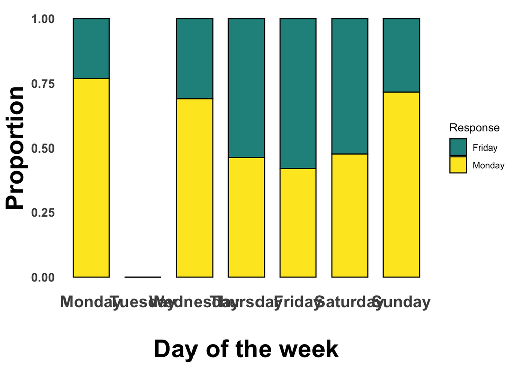

```r
weekdays <- c('Monday', 'Tuesday', 'Wednesday', 'Thursday',
              'Friday', 'Saturday', 'Sunday')
xdata %>% group_by(WeekDay) %>%
  count(Response) %>%
  filter(WeekDay != 'Tuesday') %>%
  spread(Response, n, fill = 0) %>%
  mutate(Friday = Friday / (Friday + Monday),
         Monday = 1 - Friday) %>%
  gather(key = 'Response', value = 'Proportion', -WeekDay) %>%
  ungroup %>%
  mutate(WeekDay = factor(WeekDay, levels = weekdays)) %>% bind_rows(tibble(WeekDay = factor(c('Tuesday', 'Tuesday'), levels = weekdays), Response = c('Monday', 'Friday'), Proportion = c(0, 0))) %>%
  ggplot(aes(x = WeekDay, y = Proportion, fill = Response)) +
  geom_bar(stat = 'identity', col = 'black', width = 0.7) +
  scale_fill_manual(values = c('#21908CFF', '#FDE725FF')) +
  xlab('\nDay of the week') +
  theme_minimal() +
  theme(plot.title = element_text(face = 'bold', size = 20, hjust = 0.5),
        axis.title = element_text(face = 'bold', size = 24),
        axis.text.x = element_text(face = 'bold', size = 16),
        axis.text.y = element_text(face = 'bold', size = 12),
        strip.text.x = element_text(face = 'bold', size = 20),
        plot.caption = element_text(size = 14),
        panel.grid.minor = element_blank(),
        panel.grid.major = element_blank())
```

```r
ggsave('../figures/weekday.png', width = 11.5, height = 4)
```

Make a model of this:

```r
xdata <- mutate(xdata,
                WeekDay = factor(WeekDay),
                WeekDay = relevel(WeekDay, ref = 'Wednesday'))
xdata_week <- filter(xdata,
                     WeekDay != 'Tuesday')
weekday_mdl <- brm(Response ~ WeekDay,
              data = xdata_week,
              family = bernoulli,
              init = 0,
              chains = 8,
              warmup = 2000,
              iter = 8000,
              seed = 42,
              prior = my_priors,
              control = my_controls)
```

```
## recompiling to avoid crashing R session
```

```r
weekday_null <- brm(Response ~ 1,
              data = xdata_week,
              family = bernoulli,
              init = 0,
              chains = 8,
              warmup = 2000,
              iter = 8000,
              seed = 42,
              control = my_controls)
```

```
## recompiling to avoid crashing R session
```

```r
save(weekday_mdl, file = '../models/weekday_mdl.RData')
save(weekday_null, file = '../models/weekday_null.RData')
```

Check the model:

```r
summary(weekday_mdl)
```

```
##  Family: bernoulli
##   Links: mu = logit
## Formula: Response ~ WeekDay
##    Data: xdata_week (Number of observations: 861)
## Samples: 8 chains, each with iter = 8000; warmup = 2000; thin = 1;
##          total post-warmup samples = 48000
##
## Population-Level Effects:
##                 Estimate Est.Error l-95% CI u-95% CI Eff.Sample Rhat
## Intercept          -0.64      0.27    -1.17    -0.12      12105 1.00
## WeekDayFriday       0.94      0.29     0.37     1.53      13540 1.00
## WeekDayMonday      -0.52      0.42    -1.37     0.30      18965 1.00
## WeekDaySaturday     0.72      0.29     0.15     1.30      13405 1.00
## WeekDaySunday      -0.28      0.36    -0.98     0.41      16137 1.00
## WeekDayThursday     0.77      0.30     0.20     1.36      13526 1.00
##
## Samples were drawn using sampling(NUTS). For each parameter, Eff.Sample
## is a crude measure of effective sample size, and Rhat is the potential
## scale reduction factor on split chains (at convergence, Rhat = 1).
```

Perform a LOO comparison:

```r
weekday_loo <- loo(weekday_mdl, reloo = TRUE)
```

```
## No problematic observations found. Returning the original 'loo' object.
```

```r
weekday_loo_null <- loo(weekday_null, reloo = TRUE)
```

```
## No problematic observations found. Returning the original 'loo' object.
```

```r
loo_compare(weekday_loo_null, weekday_loo)
```

```
##              elpd_diff se_diff
## weekday_mdl    0.0       0.0
## weekday_null -15.6       5.9
```

Marginal effects:

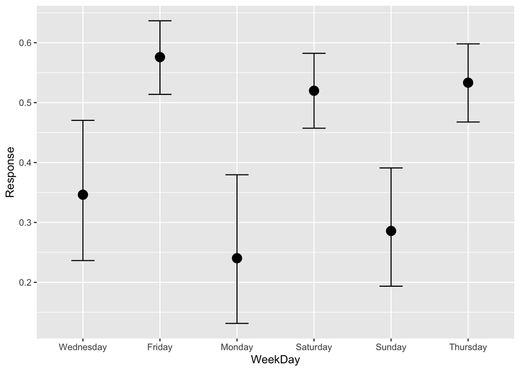

```r
marginal_effects(weekday_mdl, effects = 'WeekDay')
```

That completes this analysis.